# Health and Economic impacts of Severe Weather in the US

Nick Plummer

22/07/2018

## 1. Synopsis

Storms and severe weather can cause both public health and economic problems for communities and municipalities. Many severe events can result in fatalities, injuries, and property damage, and preventing such outcomes to the extent possible is a key concern.

This assignment explores the effect of events between 1950 and 2011 from the US NOAA storm database on:

1. Population (fatalities and injuries)
2. Economy (property damage estimates)

Data documentation:

- [National Weather Service Storm Data Documentation](https://d396qusza40orc.cloudfront.net/repdata%2Fpeer2_doc%2Fpd01016005curr.pdf)
- [National Climatic Data Center Storm Events FAQ](https://d396qusza40orc.cloudfront.net/repdata%2Fpeer2_doc%2FNCDC%20Storm%20Events-FAQ%20Page.pdf)

## 2. Data processing

Initiate R with packages required for the analysis

```r
library(knitr)
library(ggplot2)
library(gtable)
library(dplyr)
```

### 2.1 Import data

Raw data is acquired from a bzip2 compressed CSV file [on the course website](https://d396qusza40orc.cloudfront.net/repdata%2Fdata%2FStormData.csv.bz2), and subsetted to focus only on health and economic consequences.

```r
# Download file if it doesn't exist
if(!file.exists("repdata-data-StormData.csv.bz2")) {
  download.file("https://d396qusza40orc.cloudfront.net/repdata%2Fdata%2FStormData.csv.bz2",
                destfile = "repdata-data-StormData.csv.bz2", method = "curl")}
storm <- read.csv("repdata-data-StormData.csv.bz2")

# Select only data with relevance to this analysis
storm <- tbl_df(subset(storm, (FATALITIES>0|INJURIES>0|PROPDMG>0|CROPDMG>0)))

# Extract year from date
storm$YEAR <- as.numeric(format(as.Date(storm$BGN_DATE, "%m/%d/%Y %H :%M :%S"), "%Y"))
```

### 2.2 Economic data correction

Economic data is stored as value (eg PROPDMG) and the exponent (eg PROPDMGEXP), so we need to translate the exponent into a power and correct the cost by this:

```r
# Create function to derive correct exponent
getExp <- function(e) {
  if (e %in% c("h", "H"))
    return(2)
  else if (e %in% c("k", "K"))
    return(3)
  else if (e %in% c("m", "M"))
    return(6)
  else if (e %in% c("b", "B"))
    return(9)
  else if (!is.na(as.numeric(e)))
    return(as.numeric(e))
  else if (e %in% c("", "-", "?", "+"))
    return(0)
  else {
    stop("Invalid value.")
    }
}

# Calculate correct values
propExp <- sapply(storm$PROPDMGEXP, FUN=getExp)
storm$PROPDAMAGE <- storm$PROPDMG * (10 ** propExp)
rm(propExp)
cropExp <- sapply(storm$CROPDMGEXP, FUN=getExp)
storm$CROPDAMAGE <- storm$CROPDMG * (10 ** cropExp)
rm(cropExp)

# Subset for only relevant health and economic data
storm <- storm[,c("BGN_DATE", "YEAR", "EVTYPE",  # Event data
                  "FATALITIES", "INJURIES",      # Health data
                  "PROPDAMAGE", "CROPDAMAGE")]   # Economic data
```

### 2.3 Clarify event names

Normalise event names (there’s probably a quicker way to do this with REGEXP - please let me know if so!)

```r
# Hurricane
storm$EVTYPE <- gsub("^HURRICANE/TYPHOON$", "HURRICANE", storm$EVTYPE)
storm$EVTYPE <- gsub("^TROPICAL STORM$", "HURRICANE", storm$EVTYPE)
storm$EVTYPE <- gsub("^HURRICANE ERIN$", "HURRICANE", storm$EVTYPE)
storm$EVTYPE <- gsub("^HURRICANE EMILY$", "HURRICANE", storm$EVTYPE)
storm$EVTYPE <- gsub("^HURRICANE OPAL$", "HURRICANE", storm$EVTYPE)
storm$EVTYPE <- gsub("^HURRICANE OPAL/HIGH WINDS$", "HURRICANE", storm$EVTYPE)
storm$EVTYPE <- gsub("^TYPHOON$", "HURRICANE", storm$EVTYPE)
storm$EVTYPE <- gsub("^TROPICAL STORM JERRY$", "HURRICANE", storm$EVTYPE)
# Tornado
storm$EVTYPE <- gsub("^TORNADOES, TSTM WIND, HAIL$", "TORNADO", storm$EVTYPE)
storm$EVTYPE <- gsub("^WATERSPOUT$", "TORNADO", storm$EVTYPE)
storm$EVTYPE <- gsub("^WATERSPOUT/TORNADO$", "TORNADO", storm$EVTYPE)
# Thunderstorm
storm$EVTYPE <- gsub("^THUNDERSTORM WINDS$", "THUNDERSTORM", storm$EVTYPE)
storm$EVTYPE <- gsub("^THUNDERSTORM WIND$", "THUNDERSTORM", storm$EVTYPE)
storm$EVTYPE <- gsub("^TSTM WIND$", "THUNDERSTORM", storm$EVTYPE)
storm$EVTYPE <- gsub("^MARINE THUNDERSTORM WIND$", "THUNDERSTORM", storm$EVTYPE)
storm$EVTYPE <- gsub("^MARINE TSTM WIND$", "THUNDERSTORM", storm$EVTYPE)
storm$EVTYPE <- gsub("^TSTM WIND/HAIL$", "THUNDERSTORM", storm$EVTYPE)
storm$EVTYPE <- gsub("^THUNDERSTORM WINDS HAIL$", "THUNDERSTORM", storm$EVTYPE)
storm$EVTYPE <- gsub("^TSTM WIND (G45)$", "THUNDERSTORM", storm$EVTYPE)
storm$EVTYPE <- gsub("^THUNDERSTORM WINDSS$", "THUNDERSTORM", storm$EVTYPE)
storm$EVTYPE <- gsub("^THUNDERSTORM WINDS/HAIL$", "THUNDERSTORM", storm$EVTYPE)
storm$EVTYPE <- gsub("^SEVERE THUNDERSTORM$", "THUNDERSTORM", storm$EVTYPE)
storm$EVTYPE <- gsub("^SEVERE THUNDERSTORMS$", "THUNDERSTORM", storm$EVTYPE)
storm$EVTYPE <- gsub("^SEVERE THUNDERSTORM WINDS$", "THUNDERSTORM", storm$EVTYPE)
# Heavy rain
storm$EVTYPE <- gsub("^FREEZING RAIN$", "HEAVY RAIN", storm$EVTYPE)
storm$EVTYPE <- gsub("^HEAVY RAINS$", "HEAVY RAIN", storm$EVTYPE)
storm$EVTYPE <- gsub("^HEAVY RAIN/SEVERE WEATHER$", "HEAVY RAIN", storm$EVTYPE)
storm$EVTYPE <- gsub("^EXCESSIVE WETNESS$", "HEAVY RAIN", storm$EVTYPE)
# Wind
storm$EVTYPE <- gsub("^STRONG WINDS$", "WIND", storm$EVTYPE)
storm$EVTYPE <- gsub("^STRONG WIND$", "WIND", storm$EVTYPE)
storm$EVTYPE <- gsub("^MARINE STRONG WIND$", "WIND", storm$EVTYPE)
storm$EVTYPE <- gsub("^HIGH WINDS$", "WIND", storm$EVTYPE)
storm$EVTYPE <- gsub("^HIGH WIND$", "WIND", storm$EVTYPE)
storm$EVTYPE <- gsub("^GUSTY WINDS$", "WIND", storm$EVTYPE)
storm$EVTYPE <- gsub("^MARINE HIGH WIND$", "WIND", storm$EVTYPE)
storm$EVTYPE <- gsub("^WINDS$", "WIND", storm$EVTYPE)
storm$EVTYPE <- gsub("^HIGH WINDS/COLD$", "WIND", storm$EVTYPE)
# Flood
storm$EVTYPE <- gsub("^FLASH FLOOD$", "FLOOD", storm$EVTYPE)
storm$EVTYPE <- gsub("^FLOOD/FLASH FLOOD$", "FLOOD", storm$EVTYPE)
storm$EVTYPE <- gsub("^FLASH FLOOD/FLOOD$", "FLOOD", storm$EVTYPE)
storm$EVTYPE <- gsub("^FLASH FLOODING$", "FLOOD", storm$EVTYPE)
storm$EVTYPE <- gsub("^FLOODING$", "FLOOD", storm$EVTYPE)
storm$EVTYPE <- gsub("^URBAN/SML STREAM FLD$", "FLOOD", storm$EVTYPE)
storm$EVTYPE <- gsub("^URBAN FLOOD$", "FLOOD", storm$EVTYPE)
storm$EVTYPE <- gsub("^URBAN FLOODING$", "FLOOD", storm$EVTYPE)
storm$EVTYPE <- gsub("^RIVER FLOOD$", "FLOOD", storm$EVTYPE)
storm$EVTYPE <- gsub("^River Flooding$", "FLOOD", storm$EVTYPE)
storm$EVTYPE <- gsub("^MAJOR FLOOD$", "FLOOD", storm$EVTYPE)
storm$EVTYPE <- gsub("^FLOOD/RAIN/WINDS$", "FLOOD", storm$EVTYPE)
# Coastal flood
storm$EVTYPE <- gsub("^COASTAL FLOODING$", "COASTAL FLOOD", storm$EVTYPE)
storm$EVTYPE <- gsub("^COSTAL FLOOD$", "COASTAL FLOOD", storm$EVTYPE)
storm$EVTYPE <- gsub("^Coastal Flood$", "COASTAL FLOOD", storm$EVTYPE)
storm$EVTYPE <- gsub("^COASTAL FLOODING/EROSION$", "COASTAL FLOOD", storm$EVTYPE)
storm$EVTYPE <- gsub("^Erosion/Cstl Flood$", "COASTAL FLOOD", storm$EVTYPE)
# Fog
storm$EVTYPE <- gsub("^DENSE FOG$", "FOG", storm$EVTYPE)
# Snow
storm$EVTYPE <- gsub("^LAKE-EFFECT SNOW$", "SNOW", storm$EVTYPE)
storm$EVTYPE <- gsub("^Light Snow$", "SNOW", storm$EVTYPE)
storm$EVTYPE <- gsub("^HEAVY SNOW SQUALLS$", "SNOW", storm$EVTYPE)
storm$EVTYPE <- gsub("^EXCESSIVE SNOW$", "SNOW", storm$EVTYPE)
# Extreme Heat
storm$EVTYPE <- gsub("^EXCESSIVE HEAT$", "EXTREME HEAT", storm$EVTYPE)
storm$EVTYPE <- gsub("^HEAT$", "EXTREME HEAT", storm$EVTYPE)
storm$EVTYPE <- gsub("^HEAT WAVE$", "EXTREME HEAT", storm$EVTYPE)
storm$EVTYPE <- gsub("^UNSEASONABLY WARM AND DRY$", "EXTREME HEAT", storm$EVTYPE)
storm$EVTYPE <- gsub("^RECORD/EXCESSIVE HEAT$", "EXTREME HEAT", storm$EVTYPE)
# Extreme Cold
storm$EVTYPE <- gsub("^COLD$", "EXTREME COLD", storm$EVTYPE)
storm$EVTYPE <- gsub("^EXTREME WINDCHILL$", "EXTREME COLD", storm$EVTYPE)
storm$EVTYPE <- gsub("^EXTREME COLD/WIND CHILL$", "EXTREME COLD", storm$EVTYPE)
storm$EVTYPE <- gsub("^COLD/WIND CHILL$", "EXTREME COLD", storm$EVTYPE)
storm$EVTYPE <- gsub("^LOW TEMPERATURE$", "EXTREME COLD", storm$EVTYPE)
storm$EVTYPE <- gsub("^COLD WEATHER$", "EXTREME COLD", storm$EVTYPE)
storm$EVTYPE <- gsub("^COLD AND SNOW$", "EXTREME COLD", storm$EVTYPE)
storm$EVTYPE <- gsub("^RECORD COLD$", "EXTREME COLD", storm$EVTYPE)
storm$EVTYPE <- gsub("^FROST/FREEZE$", "EXTREME COLD", storm$EVTYPE)
storm$EVTYPE <- gsub("^FREEZE$", "EXTREME COLD", storm$EVTYPE)
storm$EVTYPE <- gsub("^FROST$", "EXTREME COLD", storm$EVTYPE)
storm$EVTYPE <- gsub("^Early Frost$", "EXTREME COLD", storm$EVTYPE)
storm$EVTYPE <- gsub("^DAMAGING FREEZE$", "EXTREME COLD", storm$EVTYPE)
storm$EVTYPE <- gsub("^Damaging Freeze$", "EXTREME COLD", storm$EVTYPE)
storm$EVTYPE <- gsub("^COLD AND WET CONDITIONS$", "EXTREME COLD", storm$EVTYPE)
storm$EVTYPE <- gsub("^AGRICULTURAL FREEZE$", "EXTREME COLD", storm$EVTYPE)
storm$EVTYPE <- gsub("^UNSEASONABLY COLD$", "EXTREME COLD", storm$EVTYPE)
storm$EVTYPE <- gsub("^Extreme Cold$", "EXTREME COLD", storm$EVTYPE)
storm$EVTYPE <- gsub("^HARD FREEZE$", "EXTREME COLD", storm$EVTYPE)
# Winter Storm
storm$EVTYPE <- gsub("^WINTER WEATHER$", "WINTER STORM", storm$EVTYPE)
storm$EVTYPE <- gsub("^WINTER WEATHER/MIX$", "WINTER STORM", storm$EVTYPE)
storm$EVTYPE <- gsub("^ICE STORM$", "WINTER STORM", storm$EVTYPE)
storm$EVTYPE <- gsub("^HEAVY SNOW$", "WINTER STORM", storm$EVTYPE)
storm$EVTYPE <- gsub("^BLIZZARD$", "WINTER STORM", storm$EVTYPE)
storm$EVTYPE <- gsub("^WINTER STORM HIGH WINDS$", "WINTER STORM", storm$EVTYPE)
# Snow
storm$EVTYPE <- gsub("^LIGHT SNOW$", "SNOW", storm$EVTYPE)
# Rip current
storm$EVTYPE <- gsub("^RIP CURRENTS$", "RIP CURRENT", storm$EVTYPE)
# High seas
storm$EVTYPE <- gsub("^HIGH SURF$", "HIGH SEAS", storm$EVTYPE)
storm$EVTYPE <- gsub("^HEAVY SURF/HIGH SURF$", "HIGH SEAS", storm$EVTYPE)
storm$EVTYPE <- gsub("^HEAVY SURF$", "HIGH SEAS", storm$EVTYPE)
storm$EVTYPE <- gsub("^HIGH TIDES$", "HIGH SEAS", storm$EVTYPE)
# Wildfire
storm$EVTYPE <- gsub("WILD/FOREST FIRE$", "WILDFIRE", storm$EVTYPE)
storm$EVTYPE <- gsub("WILD FIRES$", "WILDFIRE", storm$EVTYPE)
storm$EVTYPE <- gsub("WILDFIRES$", "WILDFIRE", storm$EVTYPE)
# Storm Surge
storm$EVTYPE <- gsub("STORM SURGE/TIDE$", "STORM SURGE", storm$EVTYPE)

storm$EVTYPE <- as.factor(storm$EVTYPE)
```

Finally create a cached version to avoid having to do future lengthy calculations

```r
storm.cache <- storm
```

### 2.4 Health data

Extract health data for seperate analyses, and select the 10 most common causes of mortality and morbidity:

```r
# Fatalities
fatality <- subset(storm, FATALITIES > 0) %>% group_by(EVTYPE) %>% summarise(Fatalities=sum(FATALITIES))
fatality <- fatality[order(fatality$Fatalities, decreasing = T), ]
fatality <- fatality[1:10,]

injury <- subset(storm, INJURIES > 0) %>% group_by(EVTYPE) %>% summarise(Injuries=sum(INJURIES))
injury <- injury[order(injury$Injuries, decreasing = T), ]
injury <- injury[1:10,]
```

### 2.5 Economic data

Similarly extract only the financial damage, and select the 10 most common causes for crops and property damage.

```r
property <- subset(storm, PROPDAMAGE>0) %>% group_by(EVTYPE) %>% summarise(Property=sum(PROPDAMAGE))
property <- property[order(property$Property, decreasing = T),]
property <- property[1:10,]

crops <- subset(storm, CROPDAMAGE>0) %>% group_by(EVTYPE) %>% summarise(Crops=sum(CROPDAMAGE))
crops <- crops[order(crops$Crops, decreasing = T),]
crops <- crops[1:10,]
```

## 3: Results

### 3.1: Events that are Most Harmful to Population Health

The top 10 weather events affecting the population’s health are shown below.

```r
head(injury,10)
```

```
## # A tibble: 10 x 2
##    EVTYPE       Injuries
##    <fct>           <dbl>
##  1 TORNADO         91417
##  2 THUNDERSTORM     9499
##  3 EXTREME HEAT     9089
##  4 FLOOD            8673
##  5 WINTER STORM     5607
##  6 LIGHTNING        5230
##  7 WIND             1862
##  8 HURRICANE        1669
##  9 WILDFIRE         1606
## 10 HAIL             1361
```

```r
head(fatality,10)
```

```
## # A tibble: 10 x 2
##    EVTYPE       Fatalities
##    <fct>             <dbl>
##  1 TORNADO            5664
##  2 EXTREME HEAT       3154
##  3 FLOOD              1534
##  4 LIGHTNING           816
##  5 THUNDERSTORM        726
##  6 WINTER STORM        585
##  7 RIP CURRENT         572
##  8 EXTREME COLD        465
##  9 WIND                436
## 10 AVALANCHE           224
```

Plots of injuries and fatalities demonstrate the disproportionate impact of particular weather events more clearly:

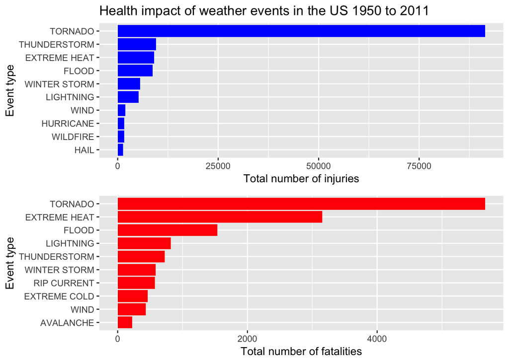

```r
p1 <- ggplot(data=injury, aes(x=reorder(EVTYPE, Injuries), y=Injuries)) +
      geom_bar(fill="blue",stat="identity")  + coord_flip() +
      ylab("Total number of injuries") + xlab("Event type") +
      ggtitle("Health impact of weather events in the US 1950 to 2011") +
      theme(legend.position="none")

p2 <- ggplot(data=fatality, aes(x=reorder(EVTYPE, Fatalities), y=Fatalities)) +
      geom_bar(fill="red",stat="identity") + coord_flip() +
      ylab("Total number of fatalities") + xlab("Event type") +
      theme(legend.position="none")

plot(rbind(ggplotGrob(p1), ggplotGrob(p2), size = "first"), width=800, height=800)
```

Tornados have clearly had the biggest impact on mortality and morbidity from adverse weather in the US, with injuries way in excess of that expected vs other weather modalities. Fatalities also arise from extremes of normal weather conditions, including heat and cold, winter storms, and flooding, with other spectacular but less devestating events accounting for much small numbers of deaths and injuries.

### 3.2: Events that have the Greatest Economic Consequences

The top 10 weather events affecting the economy are shown below.

```r
head(property,10)
```

```
## # A tibble: 10 x 2
##    EVTYPE       Property
##    <fct>           <dbl>
##  1 FLOOD         6.84e13
##  2 THUNDERSTORM  2.09e13
##  3 TORNADO       1.08e12
##  4 HAIL          3.16e11
##  5 LIGHTNING     1.73e11
##  6 HURRICANE     9.31e10
##  7 STORM SURGE   4.80e10
##  8 WINTER STORM  2.93e10
##  9 WILDFIRE      8.49e 9
## 10 WIND          6.19e 9
```

```r
head(crops,10)
```

```
## # A tibble: 10 x 2
##    EVTYPE             Crops
##    <fct>              <dbl>
##  1 DROUGHT      13972566000
##  2 FLOOD        12382903200
##  3 HURRICANE     6209963800
##  4 WINTER STORM  5315770600
##  5 EXTREME COLD  3408126500
##  6 HAIL          3025974480
##  7 THUNDERSTORM  1271669980
##  8 HEAVY RAIN     935899800
##  9 EXTREME HEAT   904413500
## 10 WIND           757250400
```

Plots of total damage to properties and crops again demonstrate that particular events have a disproportionate impact:

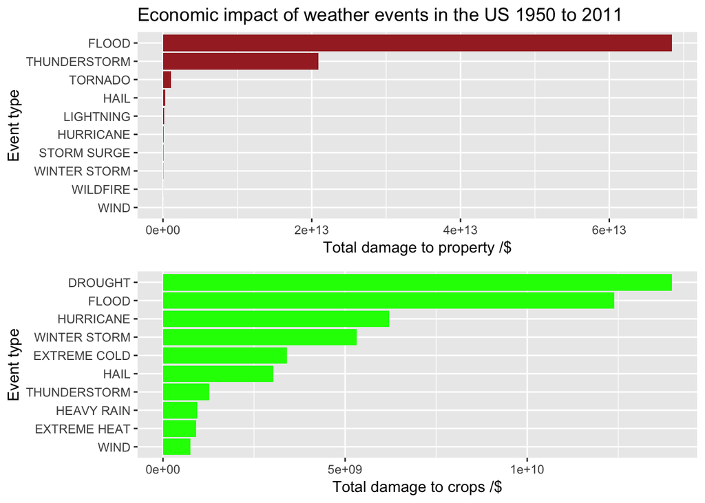

```r
p1 <- ggplot(data=property, aes(x=reorder(EVTYPE, Property), y=Property)) +
      geom_bar(fill="brown",stat="identity")  + coord_flip() +
      ylab("Total damage to property /$") + xlab("Event type") +
      ggtitle("Economic impact of weather events in the US 1950 to 2011") +
      theme(legend.position="none")

p2 <- ggplot(data=crops, aes(x=reorder(EVTYPE, Crops), y=Crops)) +
      geom_bar(fill="green",stat="identity") + coord_flip() +
      ylab("Total damage to crops /$") + xlab("Event type") +
      theme(legend.position="none")

plot(rbind(ggplotGrob(p1), ggplotGrob(p2), size = "first"), width=800, height=800)
```

Flooding in particular causes much more property damage than for examples tornados, which is the opposite to their mortality impact. The likely cause for this is that tornados are more sudden, with little time to evacuate, whereas floods although more devesatating economically can be predicted and so human life spared.